# Iteration (Completed Notebook)

R for Data Science

LDG

# Set-up

```r
library(tidyverse)
```

## Acknowledgements

This notebook is based on Chapters 21 of [*R for Data Science*](https://r4ds.had.co.nz/index.html).

# 1 The definition of madness

Einstein once said:

> “Insanity is doing the same thing over and over and expecting different results.”

That is true for life. And it is true for programming. Looping or **iteration** is about doing the **same** thing over and over again and returning **exactly** the same results.

Let’s revisit the big picture. In data science we have data and functions that do stuff to those data. For instance, calculate the mean of a column. That’s pretty much it.

Iteration **most often** enters the picture when you need to use the same function **many times** (e.g., calculate the mean of many different columns).

This is what `summarise` does for you under the hood:

```r
# load the diamonds data
data("diamonds")

# average price, table, depth
diamonds %>%
  summarise(mean(price), mean(table), mean(depth))
```

| mean(price) | mean(table) | mean(depth) |
| --- | --- | --- |
| 3932.8 | 57.45718 | 61.7494 |

in this example it applies the function `mean()` to three different columns.

## 1.1 Functional programming

R is a **functional programming** language. In a nutshell that means loops are “wrapped” inside **functions** which are then **applied** to entire vectors (rather than individual elements).

Something really confusing about R (to me, at least) is the [community’s attitude towards loops](https://stackoverflow.com/questions/30240573/are-for-loops-evil-in-r). Beginners are told to never use loops because they are slow and instead use “vectorised” solutions. But as we will shortly see, “vectorised” solutions are just loops in a faster language (C). And the slowness of a loop depends not on the loop itself but [what you do inside the loop](https://privefl.github.io/blog/why-loops-are-slow-in-r/).

Moreover, loops are really useful for one reason: they are **easy** to understand and they are an important construct to master when writing **pseudocode**, the most important programming language of all.

The `tidyverse` leans into the idea of functional programming with its family of `map` operators from the package `purrr` (which ships with `library(tidyverse)`).

## 1.2 Pseudocode

Pseudocode is executable code for humans rather than computers. Basically it’s general instructions on **how** to write code. You write down the basic idea. Implementing the idea is then just a matter of converting the pseudocode into a language the computer can read (R, Python, Visual Basic, FORTRAN, whatever).

Thinking in these terms is very important when writing programs that **iterate**. Why? Because you have to think very carefully about two things:

- the desired **input** (e.g., a numeric vector)
- the desired **output** (e.g., another numeric vector)

and more importantly this helps you think about **whether you need a loop at all** to solve your problem. If you don’t need a loop, don’t use a loop.

Later in this notebook we will write a program that uses iteration to simulate the Central Limit Theorem. The pseudocode is:

```
for each i in N simulations:
  1. draw a random sample of the data
  2. estimate a linear model
  3. extract the coefficient of interest
  4. return the coefficient
endfor
```

all we have to do is re-write the instructions in R. Not that this is trivial. But the pseudocode gives us a North Star to point to in case we get lost.

# 2 Simple loops

Consider this vector:

```r
# vector of integers 1 to 10
x = 1:10
# view it
x
```

```
 [1]  1  2  3  4  5  6  7  8  9 10
```

What if we wanted to write a loop that takes each element, multiply it by 2, and add it to a new vector called `x_2`?

The pseudocode would be something like this:

```
make an empty vector called "x2" the same length as x
for each element in x:
  multiply it by 2 and attach it to the corresponding place in x2
endfor
```

First we have to define the **output** of the loop, `x2`. It’s a vector, and we want it to hold numbers, or “doubles”, and it needs to have the same length of `x`:

```r
x2 = vector(mode = "double", length = length(x))
x2
```

```
 [1] 0 0 0 0 0 0 0 0 0 0
```

Why define the output before you have the output? Because it’s faster. Why? Because by **pre-allocating** memory you use memory more efficiently. Failure to pre-allocate when iterating is one of the main reasons why loops are “slow”. See the appendix for more details.

Next we need to set up the loop **skeleton**. This mainly consists of the **iterator** `for each element in x`. What this really says is “if `x` has $n$ elements, run the loop one time for each element and **in order** (i.e., 1, then 2, then 3, etc.)”.

There are multiple ways you can do this in R:

```r
for(i in 1:length(x)){
  print(i)
}
```

[output not shown]

or use `seq_along()`:

```r
for(i in seq_along(x)){
  print(i)
}
```

```
[1] 1
[1] 2
[1] 3
[1] 4
[1] 5
[1] 6
[1] 7
[1] 8
[1] 9
[1] 10
```

(The [book](https://r4ds.had.co.nz/iteration.html#for-loops) explains why you might prefer `seq_along()`).

Finally we define the **body** or “guts” of the loop: multiply the $i_{th}$ element of `x` by 2 and attach it to the $i_th$ element of `x2`. Remember vector indexing in R works like this: `vector[index number]`. So the iterator `i` will serve as the vector index for `x` and `x2`:

```r
for(i in seq_along(x)){
  x2[i] = x[i]*2
}
```

Let’s view the results:

```r
x2
```

```
 [1]  2  4  6  8 10 12 14 16 18 20
```

It worked!

## 2.1 Checkpoint

Write a program that loops over `x` and returns a vector `x_squared` with the square of each element of `x`:

```r
# define the output
x_squared = vector(mode = "double", length = length(x))
# run the loop
for(i in seq_along(x)){
  x_squared[i] = x[i]^2
}
# view the output
x_squared
```

```
 [1]   1   4   9  16  25  36  49  64  81 100
```

## 2.2 Vectorisation

It makes no sense to write a loop that multiples `x` by 2 when we could just do:

```r
x*2
```

```
 [1]  2  4  6  8 10 12 14 16 18 20
```

“Vectorisation” refers to a function that takes as its argument a vector. In our case it means multiplying each element by 2 “at the same time”. But this is of course impossible. You would need a quantum computer!

What is really going on is that `*` is a function and it is “vectorised” because it calls a function that runs the same loop we made, only in C, a much faster language. [Here is the source code](https://github.com/wch/r-source/blob/f05c3e60ded95a498dcd6c0ec7e66257f92fc08b/src/main/names.c#L164).

The important lesson here is that **all calculations applied to each element of a vector use loops**. The only question is whether the loop is run in a faster or slower language. And this is why looping is “discouraged” in R when there are “vectorised” solutions available. Long story short, don’t re-invent the wheel.

## 2.3 Functional programming

What if you want to make your loop more portable? Use it on **any** vector? Wrap it inside a function! This is the heart of **functional programming**.

## 2.4 Checkpoint

Write a function called `square` that takes a numerical vector and returns a vector with the square of each element of the input vector. Test it out on this vector:

```r
# vector of integers 1 to 20
test_vector = 1:20
```

```r
square = function(x){
  # first define the output
  output = vector(mode = "double", length = length(x))
  for(i in seq_along(x)){
    output[i] = x[i]^2
  }
  return(output)
}
```

```r
square(x = test_vector)
```

```
 [1]   1   4   9  16  25  36  49  64  81 100 121 144 169 196 225 256 289 324 361 400
```

## 2.5 Checkpoint

Just for the sake of practice, let’s reinvent `mean()`. Write a function called `my_mean` that calculates the mean of a numerical vector. Recall the formula for the mean:

$$\bar{x} = \frac{1}{n} \sum_{i=1}^n x_i$$

You can use `length()` to calculate $n$, but try **not** to use `sum()`in your function! Bonus if you also avoid using `length()`.

```r
my_mean = function(x){
  # 1. calculate the sum of the vector
  ## (if we used sum() it would just be sum(x))
  ## define an empty object called "sum"
  sum = 0
  ## now loop over the input and add each element to sum
  for(i in seq_along(x)){
    sum = sum + x[i]
  }
  # 2. get the length of the vector
  ## start with an empty value
  n = 0
  ## the for each element of the vector...
  for(i in seq_along(x)){
    n = n + 1 # add one!
  }
  # 3. the mean is sum/n
  mean = sum/n
  # 4. return it!
  return(mean)
}
```

Confirm that `my_mean()` returns the same results as `mean()` by calculating average price in `diamonds` inside a call to `summarise()`:

```r
diamonds %>%
  summarise(my_mean(price), mean(price))
```

| my_mean(price) | mean(price) |
| --- | --- |
| 3932.8 | 3932.8 |

(Again, don’t use `my_mean()` in real life because [`mean()` is written in C](https://github.com/wch/r-source/blob/f05c3e60ded95a498dcd6c0ec7e66257f92fc08b/src/main/names.c#L492) and therefore much faster.)

# 3 Mapping

The `tidyverse` way of looping is “mapping” through the `map` functions in `purrr`. The idea is to “map” a function to many objects “all at once” (i.e. the loops are written in C).

Consider this data set of standard normal random variables:

```r
df <- tibble(
  a = rnorm(n = 5, mean = 0, sd = 1),
  b = rnorm(n = 5, mean = 0, sd = 1),
  c = rnorm(n = 5, mean = 0, sd = 1),
  d = rnorm(n = 5, mean = 0, sd = 1)
)
df
```

| a | b | c | d |
| --- | --- | --- | --- |
| -0.5797285 | -0.4666530 | 0.9216301 | -0.25417885 |
| 0.1317783 | 0.8753449 | -0.3204941 | -0.17329095 |
| 1.5385788 | -1.3446056 | 1.3981372 | 0.51890583 |
| -0.1586313 | -0.9368919 | 1.4417777 | 1.05153012 |
| -1.7907944 | -1.7873283 | 0.2048735 | -0.08861982 |

Say you wanted to calculate the mean of each column. You could use `summarise()`, or you could write a loop that goes over each column. But a more efficient approach is to apply or **map** the function `mean`:

```r
df %>%
  map(mean)
```

```
$a
[1] -0.1717594

$b
[1] -0.7320268

$c
[1] 0.7291849

$d
[1] 0.2108693
```

### 3.0.1 Lists

The `map` functions all do the same thing but return different data types. For instance, `map_dbl` returns a numeric vector, while `map` returns a **list**.

Lists are major data objects in R – the equivalent of “dictionaries” in Python (a “list” in Python is a vector in R). Unlike vectors a list can hold many different data types. One element of a list can be a tibble, another element a vector, and so on.

When you work with data frames / tibbles you don’t spend much time with lists. But it’s useful to know who to work with lists because pretty much all objects in R are lists under the hood.

How do you know? You’re dealing with a list-type object if you can index it’s attributes with `$`. Tibbles are lists:

```r
df$a
```

```
[1] -0.5797285  0.1317783  1.5385788 -0.1586313 -1.7907944
```

and so are `lm` objects:

```r
# estimate a linear model
model = lm(formula = log(price) ~ carat + table + depth, data = diamonds)
# view the structure of the output with `$`
str(model)
```

```
List of 12
 $ coefficients : Named num [1:4] 8.0451 1.97893 -0.00854 -0.02181
  ..- attr(*, "names")= chr [1:4] "(Intercept)" "carat" "table" "depth"
 $ residuals    : Named num [1:53940] -0.902 -0.849 -0.914 -0.952 -0.969 ...
  ..- attr(*, "names")= chr [1:53940] "1" "2" "3" "4" ...
 $ effects      : Named num [1:53940] -1808.476 216.847 2.137 6.906 -0.954 ...
  ..- attr(*, "names")= chr [1:53940] "(Intercept)" "carat" "table" "depth" ...
 $ rank         : int 4
 $ fitted.values: Named num [1:53940] 6.69 6.64 6.7 6.76 6.78 ...
  ..- attr(*, "names")= chr [1:53940] "1" "2" "3" "4" ...
 $ assign       : int [1:4] 0 1 2 3
 $ qr           :List of 5
  ..$ qr   : num [1:53940, 1:4] -2.32e+02 4.31e-03 4.31e-03 4.31e-03 4.31e-03 ...
  .. ..- attr(*, "dimnames")=List of 2
  .. .. ..$ : chr [1:53940] "1" "2" "3" "4" ...
  .. .. ..$ : chr [1:4] "(Intercept)" "carat" "table" "depth"
  .. ..- attr(*, "assign")= int [1:4] 0 1 2 3
  ..$ qraux: num [1:4] 1 1.01 1.02 1
  ..$ pivot: int [1:4] 1 2 3 4
  ..$ tol  : num 1e-07
  ..$ rank : int 4
  ..- attr(*, "class")= chr "qr"
 $ df.residual  : int 53936
 $ xlevels      : Named list()
 $ call         : language lm(formula = log(price) ~ carat + table + depth, data = diamonds)
 $ terms        :Classes 'terms', 'formula'  language log(price) ~ carat + table + depth
  .. ..- attr(*, "variables")= language list(log(price), carat, table, depth)
  .. ..- attr(*, "factors")= int [1:4, 1:3] 0 1 0 0 0 0 1 0 0 0 ...
  .. .. ..- attr(*, "dimnames")=List of 2
  .. .. .. ..$ : chr [1:4] "log(price)" "carat" "table" "depth"
  .. .. .. ..$ : chr [1:3] "carat" "table" "depth"
  .. ..- attr(*, "term.labels")= chr [1:3] "carat" "table" "depth"
  .. ..- attr(*, "order")= int [1:3] 1 1 1
  .. ..- attr(*, "intercept")= int 1
  .. ..- attr(*, "response")= int 1
  .. ..- attr(*, ".Environment")=<environment: R_GlobalEnv>
  .. ..- attr(*, "predvars")= language list(log(price), carat, table, depth)
  .. ..- attr(*, "dataClasses")= Named chr [1:4] "numeric" "numeric" "numeric" "numeric"
  .. .. ..- attr(*, "names")= chr [1:4] "log(price)" "carat" "table" "depth"
 $ model        :'data.frame':  53940 obs. of  4 variables:
  ..$ log(price): num [1:53940] 5.79 5.79 5.79 5.81 5.81 ...
  ..$ carat     : num [1:53940] 0.23 0.21 0.23 0.29 0.31 0.24 0.24 0.26 0.22 0.23 ...
  ..$ table     : num [1:53940] 55 61 65 58 58 57 57 55 61 61 ...
  ..$ depth     : num [1:53940] 61.5 59.8 56.9 62.4 63.3 62.8 62.3 61.9 65.1 59.4 ...
  ..- attr(*, "terms")=Classes 'terms', 'formula'  language log(price) ~ carat + table + depth
  .. .. ..- attr(*, "variables")= language list(log(price), carat, table, depth)
  .. .. ..- attr(*, "factors")= int [1:4, 1:3] 0 1 0 0 0 0 1 0 0 0 ...
  .. .. .. ..- attr(*, "dimnames")=List of 2
  .. .. .. .. ..$ : chr [1:4] "log(price)" "carat" "table" "depth"
  .. .. .. .. ..$ : chr [1:3] "carat" "table" "depth"
  .. .. ..- attr(*, "term.labels")= chr [1:3] "carat" "table" "depth"
  .. .. ..- attr(*, "order")= int [1:3] 1 1 1
  .. .. ..- attr(*, "intercept")= int 1
  .. .. ..- attr(*, "response")= int 1
  .. .. ..- attr(*, ".Environment")=<environment: R_GlobalEnv>
  .. .. ..- attr(*, "predvars")= language list(log(price), carat, table, depth)
  .. .. ..- attr(*, "dataClasses")= Named chr [1:4] "numeric" "numeric" "numeric" "numeric"
  .. .. .. ..- attr(*, "names")= chr [1:4] "log(price)" "carat" "table" "depth"
 - attr(*, "class")= chr "lm"
```

And the `summary()` of a linear model object is a list:

```r
summary_model = summary(model)
str(summary_model)
```

```
List of 11
 $ call         : language lm(formula = log(price) ~ carat + table + depth, data = diamonds)
 $ terms        :Classes 'terms', 'formula'  language log(price) ~ carat + table + depth
  .. ..- attr(*, "variables")= language list(log(price), carat, table, depth)
  .. ..- attr(*, "factors")= int [1:4, 1:3] 0 1 0 0 0 0 1 0 0 0 ...
  .. .. ..- attr(*, "dimnames")=List of 2
  .. .. .. ..$ : chr [1:4] "log(price)" "carat" "table" "depth"
  .. .. .. ..$ : chr [1:3] "carat" "table" "depth"
  .. ..- attr(*, "term.labels")= chr [1:3] "carat" "table" "depth"
  .. ..- attr(*, "order")= int [1:3] 1 1 1
  .. ..- attr(*, "intercept")= int 1
  .. ..- attr(*, "response")= int 1
  .. ..- attr(*, ".Environment")=<environment: R_GlobalEnv>
  .. ..- attr(*, "predvars")= language list(log(price), carat, table, depth)
  .. ..- attr(*, "dataClasses")= Named chr [1:4] "numeric" "numeric" "numeric" "numeric"
  .. .. ..- attr(*, "names")= chr [1:4] "log(price)" "carat" "table" "depth"
 $ residuals    : Named num [1:53940] -0.902 -0.849 -0.914 -0.952 -0.969 ...
  ..- attr(*, "names")= chr [1:53940] "1" "2" "3" "4" ...
 $ coefficients : num [1:4, 1:4] 8.0451 1.97893 -0.00854 -0.02181 0.10143 ...
  ..- attr(*, "dimnames")=List of 2
  .. ..$ : chr [1:4] "(Intercept)" "carat" "table" "depth"
  .. ..$ : chr [1:4] "Estimate" "Std. Error" "t value" "Pr(>|t|)"
 $ aliased      : Named logi [1:4] FALSE FALSE FALSE FALSE
  ..- attr(*, "names")= chr [1:4] "(Intercept)" "carat" "table" "depth"
 $ sigma        : num 0.396
 $ df           : int [1:3] 4 53936 4
 $ r.squared    : num 0.848
 $ adj.r.squared: num 0.848
 $ fstatistic   : Named num [1:3] 100085 3 53936
  ..- attr(*, "names")= chr [1:3] "value" "numdf" "dendf"
 $ cov.unscaled : num [1:4, 1:4] 0.065616 0.000307 -0.000363 -0.000728 0.000307 ...
  ..- attr(*, "dimnames")=List of 2
  .. ..$ : chr [1:4] "(Intercept)" "carat" "table" "depth"
  .. ..$ : chr [1:4] "(Intercept)" "carat" "table" "depth"
 - attr(*, "class")= chr "summary.lm"
```

So if you want to access only the R-squared of the summary object:

```r
summary_model$r.squared
```

```
[1] 0.8477212
```

or the residual standard deviation `sigma` (the standard deviation of the residuals):

```r
summary_model$sigma
```

```
[1] 0.3959568
```

## 3.1 Mapping over models

Why is this important? Because you might want to run many models and then look at just one piece of each model.

We know we run a regression like so:

```r
diamonds %>%
  lm(formula = log(price) ~ carat, data = .) %>%
  summary()
```

```
Call:
lm(formula = log(price) ~ carat, data = .)

Residuals:
    Min      1Q  Median      3Q     Max
-6.2844 -0.2449  0.0335  0.2578  1.5642

Coefficients:
            Estimate Std. Error t value Pr(>|t|)
(Intercept) 6.215021   0.003348    1856   <2e-16 ***
carat       1.969757   0.003608     546   <2e-16 ***
---
Signif. codes:  0 ‘***’ 0.001 ‘**’ 0.01 ‘*’ 0.05 ‘.’ 0.1 ‘ ’ 1

Residual standard error: 0.3972 on 53938 degrees of freedom
Multiple R-squared:  0.8468,    Adjusted R-squared:  0.8468
F-statistic: 2.981e+05 on 1 and 53938 DF,  p-value: < 2.2e-16
```

But what if we want to **split** the data by some grouping variable (e.g., `cut`) and then estimate the model for each tibble?

The function [`split()`](https://www.rdocumentation.org/packages/base/versions/3.6.2/topics/split) will split our data in a list:

```r
diamonds%>%
  split(.$cut)
```

| carat | cut | color | clarity | depth | table | price | x | y | z |
| --- | --- | --- | --- | --- | --- | --- | --- | --- | --- |
| 0.22 | Fair | E | VS2 | 65.1 | 61.0 | 337 | 3.87 | 3.78 | 2.49 |
| 0.86 | Fair | E | SI2 | 55.1 | 69.0 | 2757 | 6.45 | 6.33 | 3.52 |
| 0.96 | Fair | F | SI2 | 66.3 | 62.0 | 2759 | 6.27 | 5.95 | 4.07 |
| 0.70 | Fair | F | VS2 | 64.5 | 57.0 | 2762 | 5.57 | 5.53 | 3.58 |
| 0.70 | Fair | F | VS2 | 65.3 | 55.0 | 2762 | 5.63 | 5.58 | 3.66 |
| 0.91 | Fair | H | SI2 | 64.4 | 57.0 | 2763 | 6.11 | 6.09 | 3.93 |
| 0.91 | Fair | H | SI2 | 65.7 | 60.0 | 2763 | 6.03 | 5.99 | 3.95 |
| 0.98 | Fair | H | SI2 | 67.9 | 60.0 | 2777 | 6.05 | 5.97 | 4.08 |
| 0.84 | Fair | G | SI1 | 55.1 | 67.0 | 2782 | 6.39 | 6.20 | 3.47 |
| 1.01 | Fair | E | I1 | 64.5 | 58.0 | 2788 | 6.29 | 6.21 | 4.03 |

[output cut: 990 more lines]

| carat | cut | color | clarity | depth | table | price | x | y | z |
| --- | --- | --- | --- | --- | --- | --- | --- | --- | --- |
| 0.23 | Good | E | VS1 | 56.9 | 65.0 | 327 | 4.05 | 4.07 | 2.31 |
| 0.31 | Good | J | SI2 | 63.3 | 58.0 | 335 | 4.34 | 4.35 | 2.75 |
| 0.30 | Good | J | SI1 | 64.0 | 55.0 | 339 | 4.25 | 4.28 | 2.73 |
| 0.30 | Good | J | SI1 | 63.4 | 54.0 | 351 | 4.23 | 4.29 | 2.70 |
| 0.30 | Good | J | SI1 | 63.8 | 56.0 | 351 | 4.23 | 4.26 | 2.71 |
| 0.30 | Good | I | SI2 | 63.3 | 56.0 | 351 | 4.26 | 4.30 | 2.71 |
| 0.23 | Good | F | VS1 | 58.2 | 59.0 | 402 | 4.06 | 4.08 | 2.37 |
| 0.23 | Good | E | VS1 | 64.1 | 59.0 | 402 | 3.83 | 3.85 | 2.46 |
| 0.31 | Good | H | SI1 | 64.0 | 54.0 | 402 | 4.29 | 4.31 | 2.75 |
| 0.26 | Good | D | VS2 | 65.2 | 56.0 | 403 | 3.99 | 4.02 | 2.61 |

[output cut: 990 more lines]

```
$`Very Good`
```

| carat | cut | color | clarity | depth | table | price | x | y | z |
| --- | --- | --- | --- | --- | --- | --- | --- | --- | --- |
| 0.24 | Very Good | J | VVS2 | 62.8 | 57.0 | 336 | 3.94 | 3.96 | 2.48 |
| 0.24 | Very Good | I | VVS1 | 62.3 | 57.0 | 336 | 3.95 | 3.98 | 2.47 |
| 0.26 | Very Good | H | SI1 | 61.9 | 55.0 | 337 | 4.07 | 4.11 | 2.53 |
| 0.23 | Very Good | H | VS1 | 59.4 | 61.0 | 338 | 4.00 | 4.05 | 2.39 |
| 0.30 | Very Good | J | SI1 | 62.7 | 59.0 | 351 | 4.21 | 4.27 | 2.66 |
| 0.23 | Very Good | E | VS2 | 63.8 | 55.0 | 352 | 3.85 | 3.92 | 2.48 |
| 0.23 | Very Good | H | VS1 | 61.0 | 57.0 | 353 | 3.94 | 3.96 | 2.41 |
| 0.31 | Very Good | J | SI1 | 59.4 | 62.0 | 353 | 4.39 | 4.43 | 2.62 |
| 0.31 | Very Good | J | SI1 | 58.1 | 62.0 | 353 | 4.44 | 4.47 | 2.59 |
| 0.23 | Very Good | G | VVS2 | 60.4 | 58.0 | 354 | 3.97 | 4.01 | 2.41 |

[output cut: 990 more lines]

| carat | cut | color | clarity | depth | table | price | x | y | z |
| --- | --- | --- | --- | --- | --- | --- | --- | --- | --- |
| 0.21 | Premium | E | SI1 | 59.8 | 61.0 | 326 | 3.89 | 3.84 | 2.31 |
| 0.29 | Premium | I | VS2 | 62.4 | 58.0 | 334 | 4.20 | 4.23 | 2.63 |
| 0.22 | Premium | F | SI1 | 60.4 | 61.0 | 342 | 3.88 | 3.84 | 2.33 |
| 0.20 | Premium | E | SI2 | 60.2 | 62.0 | 345 | 3.79 | 3.75 | 2.27 |
| 0.32 | Premium | E | I1 | 60.9 | 58.0 | 345 | 4.38 | 4.42 | 2.68 |
| 0.24 | Premium | I | VS1 | 62.5 | 57.0 | 355 | 3.97 | 3.94 | 2.47 |
| 0.29 | Premium | F | SI1 | 62.4 | 58.0 | 403 | 4.24 | 4.26 | 2.65 |
| 0.22 | Premium | E | VS2 | 61.6 | 58.0 | 404 | 3.93 | 3.89 | 2.41 |
| 0.22 | Premium | D | VS2 | 59.3 | 62.0 | 404 | 3.91 | 3.88 | 2.31 |
| 0.30 | Premium | J | SI2 | 59.3 | 61.0 | 405 | 4.43 | 4.38 | 2.61 |

[output cut: 990 more lines]

| carat | cut | color | clarity | depth | table | price | x | y | z |
| --- | --- | --- | --- | --- | --- | --- | --- | --- | --- |
| 0.23 | Ideal | E | SI2 | 61.5 | 55.0 | 326 | 3.95 | 3.98 | 2.43 |
| 0.23 | Ideal | J | VS1 | 62.8 | 56.0 | 340 | 3.93 | 3.90 | 2.46 |
| 0.31 | Ideal | J | SI2 | 62.2 | 54.0 | 344 | 4.35 | 4.37 | 2.71 |
| 0.30 | Ideal | I | SI2 | 62.0 | 54.0 | 348 | 4.31 | 4.34 | 2.68 |
| 0.33 | Ideal | I | SI2 | 61.8 | 55.0 | 403 | 4.49 | 4.51 | 2.78 |
| 0.33 | Ideal | I | SI2 | 61.2 | 56.0 | 403 | 4.49 | 4.50 | 2.75 |
| 0.33 | Ideal | J | SI1 | 61.1 | 56.0 | 403 | 4.49 | 4.55 | 2.76 |
| 0.23 | Ideal | G | VS1 | 61.9 | 54.0 | 404 | 3.93 | 3.95 | 2.44 |
| 0.32 | Ideal | I | SI1 | 60.9 | 55.0 | 404 | 4.45 | 4.48 | 2.72 |
| 0.30 | Ideal | I | SI2 | 61.0 | 59.0 | 405 | 4.30 | 4.33 | 2.63 |

[output cut: 990 more lines]

```
NA
```

and the output is a list:

```r
diamonds %>%
  split(.$cut) %>%
  class()
```

```
[1] "list"
```

so we can `map` the linear model `lm(formula = log(price) ~ carat, data = .)` onto each element of the list:

```r
diamonds %>%
  split(.$cut) %>%
  map(function(x) lm(formula = log(price) ~ carat, data = x)) # notice the x! It's the argument to this "lambda" function ( a function defined inside a function)
```

```
$Fair

Call:
lm(formula = log(price) ~ carat, data = x)

Coefficients:
(Intercept)        carat
      6.785        1.251


$Good

Call:
lm(formula = log(price) ~ carat, data = x)

Coefficients:
(Intercept)        carat
      6.164        1.977


$`Very Good`

Call:
lm(formula = log(price) ~ carat, data = x)

Coefficients:
(Intercept)        carat
      6.115        2.088


$Premium

Call:
lm(formula = log(price) ~ carat, data = x)

Coefficients:
(Intercept)        carat
      6.298        1.853


$Ideal

Call:
lm(formula = log(price) ~ carat, data = x)

Coefficients:
(Intercept)        carat
      6.147        2.124
```

and then we can `map` the `summary()` function to each estimated model:

```r
diamonds %>%
  split(.$cut) %>%
  map(function(x) lm(formula = log(price) ~ carat, data = x)) %>%
  map(summary)
```

```
$Fair

Call:
lm(formula = log(price) ~ carat, data = x)

Residuals:
    Min      1Q  Median      3Q     Max
-3.2527 -0.2229  0.0548  0.2632  1.2471

Coefficients:
            Estimate Std. Error t value Pr(>|t|)
(Intercept)  6.78482    0.02321  292.26   <2e-16 ***
carat        1.25091    0.01990   62.86   <2e-16 ***
---
Signif. codes:  0 ‘***’ 0.001 ‘**’ 0.01 ‘*’ 0.05 ‘.’ 0.1 ‘ ’ 1

Residual standard error: 0.4122 on 1608 degrees of freedom
Multiple R-squared:  0.7108,    Adjusted R-squared:  0.7106
F-statistic:  3951 on 1 and 1608 DF,  p-value: < 2.2e-16


$Good

Call:
lm(formula = log(price) ~ carat, data = x)

Residuals:
     Min       1Q   Median       3Q      Max
-2.80292 -0.26122  0.06681  0.26879  1.53479

Coefficients:
            Estimate Std. Error t value Pr(>|t|)
(Intercept)  6.16355    0.01201   513.4   <2e-16 ***
carat        1.97750    0.01247   158.6   <2e-16 ***
---
Signif. codes:  0 ‘***’ 0.001 ‘**’ 0.01 ‘*’ 0.05 ‘.’ 0.1 ‘ ’ 1

Residual standard error: 0.3965 on 4904 degrees of freedom
Multiple R-squared:  0.8369,    Adjusted R-squared:  0.8368
F-statistic: 2.515e+04 on 1 and 4904 DF,  p-value: < 2.2e-16
```

[output cut: 48 more lines]

```

Residuals:
    Min      1Q  Median      3Q     Max
-4.1397 -0.2229  0.0210  0.2383  1.4408

Coefficients:
            Estimate Std. Error t value Pr(>|t|)
(Intercept) 6.146784   0.004852  1266.8   <2e-16 ***
carat       2.123797   0.005878   361.3   <2e-16 ***
---
Signif. codes:  0 ‘***’ 0.001 ‘**’ 0.01 ‘*’ 0.05 ‘.’ 0.1 ‘ ’ 1

Residual standard error: 0.3735 on 21549 degrees of freedom
Multiple R-squared:  0.8583,    Adjusted R-squared:  0.8583
F-statistic: 1.305e+05 on 1 and 21549 DF,  p-value: < 2.2e-16
```

and even extract a single element of each `summary`, e.g. the R-squared value:

```r
diamonds %>%
  split(.$cut) %>%
  map(function(x) lm(formula = log(price) ~ carat, data = x)) %>%
  map(summary) %>%
  map(~.$r.squared)
```

```
$Fair
[1] 0.7107574

$Good
[1] 0.8368502

$`Very Good`
[1] 0.8549665

$Premium
[1] 0.8589056

$Ideal
[1] 0.8583142
```

## 3.2 Checkpoint

Write a program that splits `diamonds` by `color` and estimates log price as a function of carats and depth on each split. Which color’s model had the lowest residual standard error (`sigma`)?

```r
diamonds %>%
  split(.$color) %>%
  map(function(x) lm(formula = log(price) ~ carat + depth, data = x)) %>%
  map(summary) %>%
  map_dbl(~.$sigma)
```

```
        D         E         F         G         H         I         J
0.3508852 0.3274551 0.3450613 0.3617249 0.3767596 0.3697129 0.3682481
```

## 3.3 Mapping vs the apply family

Base R has a set of `apply` functions that work the same (and are just as fast) as the `map` family of functions. Read more [here](https://stackoverflow.com/questions/45101045/why-use-purrrmap-instead-of-lapply).

# 4 The Central Limit Theorem

Consider a linear regression of log prices as a function of table:

```r
lm(formula = log(price) ~ table, data = diamonds)
```

```
Call:
lm(formula = log(price) ~ table, data = diamonds)

Coefficients:
(Intercept)        table
    3.65905      0.07184
```

The coefficient on `table` in the full data set is 0.07. But regression coefficients are **random variables.** To see this, draw a random sample and re-run the regression (play this chunk a few times):

```r
diamonds %>%
  slice_sample(n = 30) %>%
  lm(formula = log(price) ~ table, data = .)
```

```
Call:
lm(formula = log(price) ~ table, data = .)

Coefficients:
(Intercept)        table
    13.6470      -0.1022
```

The coefficient bounces around with each new sample. Why? Because regression coefficients (like all **sample statistics** estimating **population parameters**) are random variables!

The **Central Limit Theorem** says that **sampling distribution** of a regression coefficient will be normal and centered at it’s expected value (i.e. the population mean). So if we were to run this experiment many times with `diamonds` (draw a sample, run a regression) we would see a distribution of regression coefficients centered at around 0.07.

Let’s use iteration to recover the sampling distribution of the regression coefficient on `table` and see the Central Limit Theorem in action.

The goal with this example is to get you thinking about how you can take one action (draw a sample, run a regression), turn it into a function, and then run that function many times.

## 4.1 One sample

Let’s start with one random sample:

```r
diamonds %>%
  slice_sample(n = 30) %>%
  lm(formula = log(price) ~ table, data = .)
```

```
Call:
lm(formula = log(price) ~ table, data = .)

Coefficients:
(Intercept)        table
   7.351740     0.008632
```

We’re interested in the coefficient on `table`. We can extract coefficients from a `lm` object with the function `coef()`:

```r
diamonds %>%
  slice_sample(n = 30) %>%
  lm(formula = log(price) ~ table, data = .) %>%
  coef()
```

```
(Intercept)       table
 -5.1135756   0.2300307
```

`coef()` returns a numeric vector:

```r
diamonds %>%
  slice_sample(n = 30) %>%
  lm(formula = log(price) ~ table, data = .) %>%
  coef() %>%
  class()
```

```
[1] "numeric"
```

whose second element is the coefficient on `table`. That’s the piece of information we want to keep.

## 4.2 Checkpoint

Use the examples above to write code that takes `diamonds`, draws a random sample of 30 observations, runs the regression (log price as a function of table), and assigns the coefficients to a vector called `betas`.

```r
betas = diamonds %>%
  slice_sample(n = 30) %>%
  lm(formula = log(price) ~ table, data = .) %>%
  coef()
```

Assign the second element of `betas` to the object `beta_`:

```r
beta_1 = betas[2]
```

View `beta_1`:

```r
beta_1
```

```
      table
-0.01759162
```

## 4.3 Subsetting with the pipe

If we want to avoid creating an intermediary object `betas` and only keep `beta_1` we can subset `.` after `coef()`:

```r
diamonds %>%
  slice_sample(n = 30) %>%
  lm(formula = log(price) ~ table, data = .) %>%
  coef() %>%
  .[2]
```

```
    table
0.1908739
```

## 4.4 Checkpoint

Turn the code you just wrote into a function called `lm_sampler` that takes an argument `sample_size` (defaulting to 30) and returns **only** the coefficient on `table`.

```r
lm_sampler = function(sample_size=30){
  beta_1 = diamonds %>%
    slice_sample(n = 30) %>%
    lm(formula = log(price) ~ table, data = .) %>%
    coef() %>%
    .[2]
  return(beta_1)
}
```

Play it a few times:

```r
lm_sampler(sample_size = 30)
```

```
     table
-0.0206476
```

## 4.5 Many samples

Now we just need to scale this to run many samples and collect many coefficients. This will be the main **body** of our loop.

Suppose want to run 100 simulations

```r
n_sims = 100
```

Let’s set up the **output** of our loop, an empty numeric vector called `betas` of length `n_sims`:

first set up an empty vector:

```r
betas = vector("double", length = n_sims)
```

And now let’s think about the loop.

At at high level our loop will look like this:

```r
for(i in seq_along(betas)){
  # sample, regress, return the coefficient
}
```

Since `lm_sampler` returns a single number (the regression coefficient), on the i-th run of `lm_sampler`, we assign the coefficient to the i-th value of `betas`.

Let’s run it:

```r
for(i in seq_along(betas)){
  betas[i] = lm_sampler(sample_size = 30)
}
```

View the output:

```r
betas
```

```
  [1]  0.0373648384  0.1007167488  0.0374748548  0.0816243558  0.0981774766
  [6]  0.1009007360  0.0900070346  0.0803810247  0.1587780382  0.1567878424
 [11] -0.0053931381  0.1506902626  0.0380578391  0.0950906853  0.3782696511
 [16] -0.0053336283  0.0652926029  0.0083030814  0.0143193305 -0.0294493646
 [21]  0.0390856536  0.2500974314  0.0886805951  0.2131391297 -0.1782070591
 [26]  0.1960762921  0.0756415413  0.0523193609  0.1161074096  0.1418404986
 [31]  0.0880674226 -0.0315184461  0.0434383968 -0.0974639621  0.0814845778
 [36]  0.1820401017  0.0103756568  0.1303736830  0.0142663357  0.0112442308
 [41]  0.1801361092  0.0078340515  0.0061664808 -0.1203981318  0.1306002967
 [46] -0.1365979645  0.1775004131  0.0999527896  0.0372036437  0.2037224385
 [51]  0.1501231849  0.0886167517  0.1479924396  0.1394686654  0.0349873651
 [56]  0.1427380952  0.0183281236  0.0684611352 -0.0067121591  0.0574731123
 [61]  0.1715373982 -0.0719094601  0.1792294578  0.0358817575  0.0787585497
 [66]  0.0776506816  0.1227480494  0.0809027890 -0.1029299303  0.0733569716
 [71]  0.0695671772 -0.0739436751 -0.0614158975  0.0362911940  0.0960662777
 [76]  0.0505582896  0.1751830458  0.0753878923  0.0012809378  0.1080359369
 [81]  0.1276328861  0.1160432669 -0.1387371489  0.0891342990  0.0565193663
 [86]  0.1864235394  0.1547382152  0.1663916156 -0.0151275471  0.0722751502
 [91]  0.0200290214 -0.0233323415  0.2440803068  0.1521616741  0.1188900243
 [96]  0.1338587673 -0.0100580282 -0.0539397797 -0.0001000065  0.0668474832
```

Great! Now let’s plot the distribution. We need to convert `betas` to a tibble so we can use `ggplot`:

```r
betas_tbl = tibble(betas)
```

Now plot:

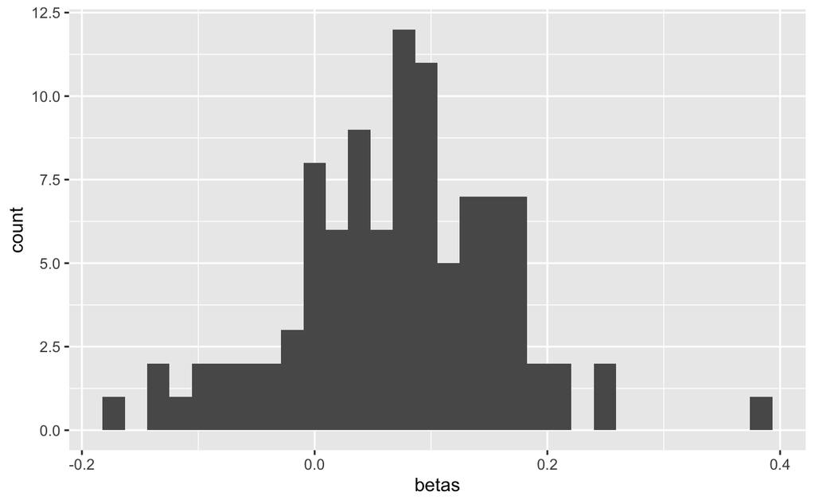

```r
ggplot(data = betas_tbl, aes(x = betas)) +
  geom_histogram()
```

The Central Limit Theorem says that if we keep running simulations (i.e. infinite simulations), eventually this distribution will become perfectly normal and centered at the “true” value of $\beta_1$.

## 4.6 Checkpoint

Use the code above to write `lm_sampler2` with **functional programming**. It should take two arguments, `sample_size = 30` and `n_sims = 100`, run the loop, and and return a tibble.

```r
lm_sampler2 = function(sample_size = 30, n_sims = 100){
  betas = vector("double", length = n_sims)
  for(i in seq_along(betas)){
    betas[i] = diamonds %>%
      slice_sample(n = 30) %>%
      lm(formula = log(price) ~ table, data = .) %>%
      coef() %>%
      .[2]
  }
  betas_tbl = tibble(betas)
  return(betas_tbl)
}
```

## 4.7 Checkpoint

Run `lm_sampler2` for 10 simulations and plot the sampling distribution. Since `lm_sampler2` returns a tibble you can pipe the output straight to `ggplot`:

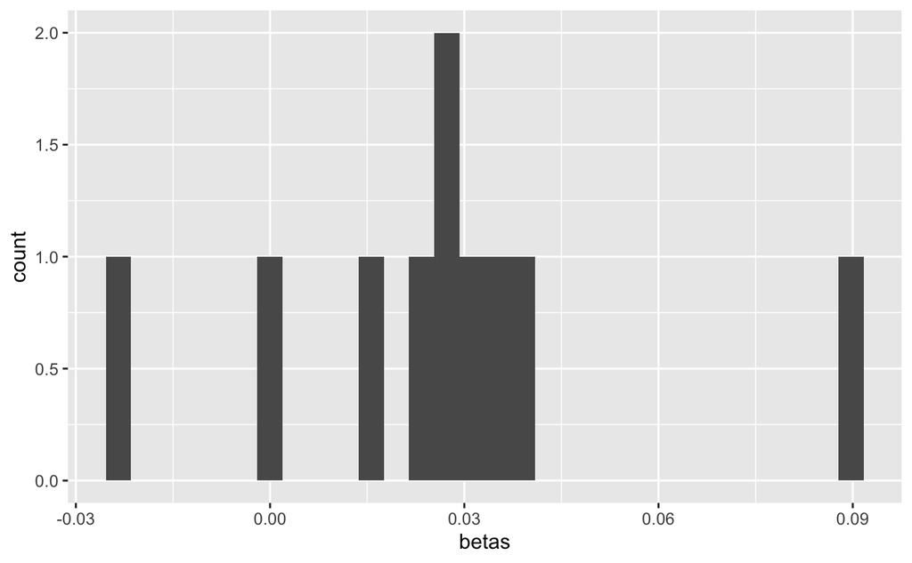

```r
lm_sampler2(sample_size = 30, n_sims=10) %>%
  ggplot(data = ., aes(x = betas)) +
  geom_histogram()
```

## 4.8 Checkpoint

Run `lm_sampler2` for 1000 simulations and plot the sampling distribution:

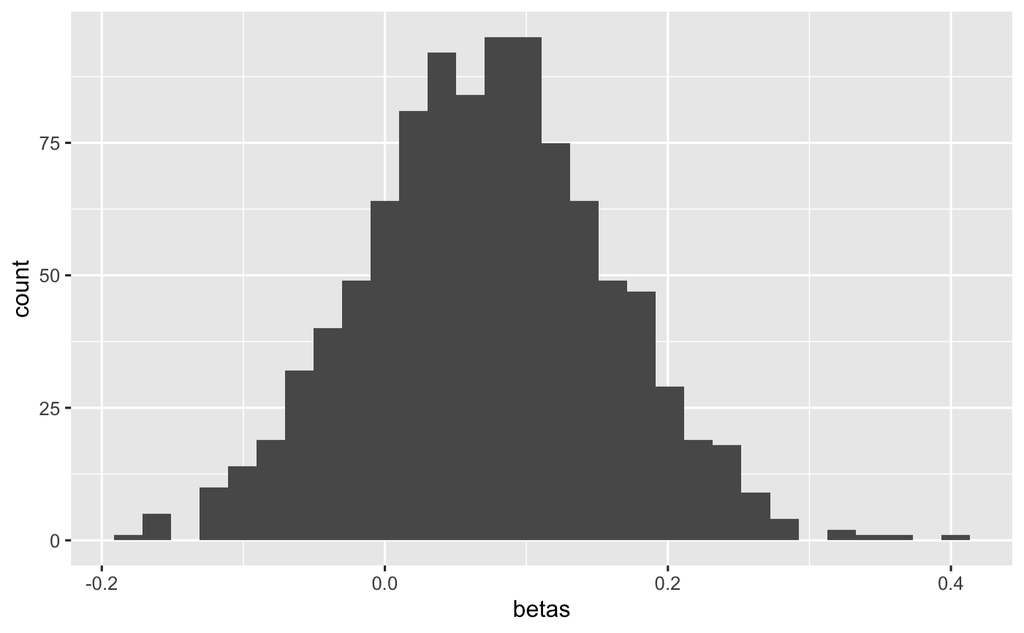

```r
lm_sampler2(sample_size = 30, n_sims=1000) %>%
  ggplot(data = ., aes(x = betas)) +
  geom_histogram()
```

That’s the Central Limit Theorem!

A nice extension is to re-write `lm_sampler2` so it also extracts the p-values of each regression. Then you can plot the hypothesis tests of the simulations and see how the false-positive error rate varies with a) the sample size in each simulation and b) the number of simulations. We leave this to the reader.

# 5 Appendix

## 5.1 Preallocating memory

```r
big_vector = 1:10^3
```

No pre-allocation:

```r
output_naive = c()
length(output_naive)
```

```
[1] 0
```

With pre-allocation:

```r
output_preallocated = vector(mode = "double", length = length(big_vector))
length(output_preallocated)
```

```
[1] 1000
```

Run the speed tests. This requires the package `microbenchmark`.

**Heads up!** This might take awhile to run on your machine.

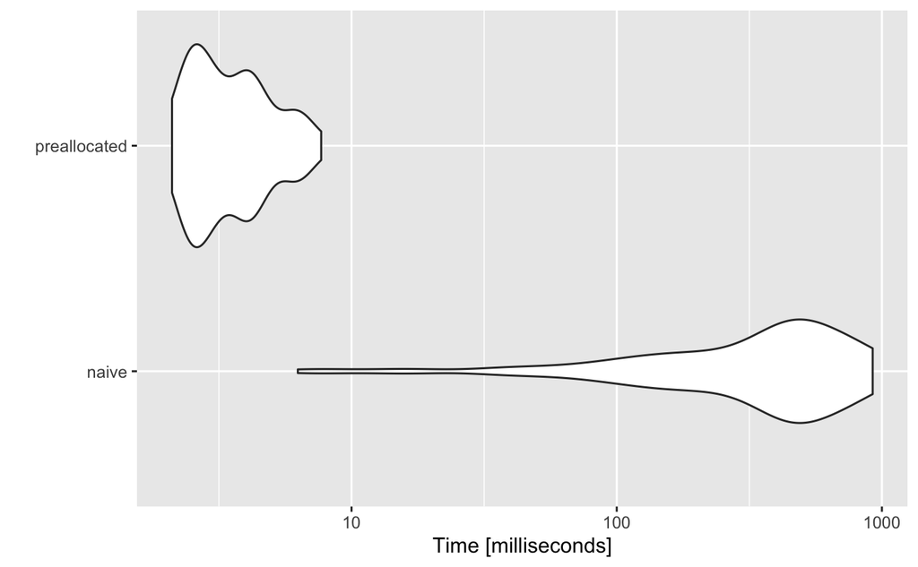

```r
speed_tests = microbenchmark::microbenchmark(
  ## the naive loop
  "naive" = for(i in seq_along(big_vector)){
    output_naive = append(output_naive, big_vector[i]^2)
  },
  ## the preallocated loop
  "preallocated" = for(i in seq_along(big_vector)){
    output_preallocated[i] = big_vector[i]^2
  },
  times = 100 # number of times to run the test
)
# plot the output
ggplot2::autoplot(speed_tests)
```

## 5.2 `replicate()`

R has a built-in function called `replicate` that will replicate a function many times. Learn more [here](https://www.rdocumentation.org/packages/Rpdb/versions/2.2/topics/replicate).

## 5.3 Using `map` with regular expressions

Here is an example of mapping in a question I answered on Piazza.

The OP has a data set where each row is a firm and a column records violations. An example cell entry looks like this:

```r
x1 = "23. PROPER DATE MARKING AND DISPOSITION - Comments: MUST PROVIDE DATE MARKINGS TO TCS/RTE FOODS, PREPARED ONSITE AND HELD IN COOLERS OVER 24 HRS. INSTRUCTED TO PROVIDE CONSUME BY DATES AND MAINTAIN. PRIORITY FOUNDATION 7-38-005 NO CITATION ISSUED. | 37. FOOD PROPERLY LABELED; ORIGINAL CONTAINER - Comments: MUST LABEL FOOD STORAGE CONTAINERS WITH COMMON FOOD NAMES; FLOUR, SUGAR, ETC., WHEN FOOD HAS BEEN REMOVED FROM ORIGINAL PACKAGING. INSTRUCTED TO MAINTAIN. | 41. WIPING CLOTHS: PROPERLY USED & STORED - Comments: MUST STORE WIPING CLOTHS IN PREP AREAS IN SANITIZER BUCKET BETWEEN USES TO PREVENT CROSS CONTAMINATION. INSTRUCTED TO MAINTAIN. | 47. FOOD & NON-FOOD CONTACT SURFACES CLEANABLE, PROPERLY DESIGNED, CONSTRUCTED & USED - Comments: FOUND TORN REFRIGERATION GASKETS ON MULTIPLE REFRIGERATION UNITS THROUGHOUT FACILITY. INSTRUCTED FACILITY TO REPLACE ALL TORN GASKETS AND MAINTAIN"
```

```r
x2 = "36. THERMOMETERS PROVIDED & ACCURATE - Comments: 4-204.112(B) NOTED NO THERMOMETERS INSIDE FOUR DISPLAY COOLER UNITS CONSPICUOUSLY POSTED TO MONITOR THE AMBIENT AIR TEMPERATURE OF EQUIPMENT. INSTRUCTED TO EQUIP ALL REFRIGERATION UNITS WITH ACCURATE AND WORKING THERMOMETERS. | 53. TOILET FACILITIES: PROPERLY CONSTRUCTED, SUPPLIED, & CLEANED - Comments: 5-501.17 OBSERVED NO COVERED RECEPTACLE (WASTE CAN WITH LID) IN UNISEX EMPLOYEE WASHROOM. INSTRUCTED TO PROVIDE COVERED WASTE RECEPTACLE. "
```

Suppose you wanted to **count** the number of unique violations for each firm and make that into a new column. Looks like each violation is uniquely identified with a number (e.g., “23. PROPER DATE MARKING AND DISPOSITION”) and specifically this pattern: “##.” (i.e. number then period then space).

This is a problem of [regular expressions](https://en.wikipedia.org/wiki/Regular_expression) You can use [`stringr`](https://stringr.tidyverse.org/) to do regular expressions. It ships with the `tidyverse`.

You can solve this problem with `str_match_all()`, a function that looks for and returns all instances of a text pattern. The hardest part is to correctly specifying the pattern (regex is a **huge** pain). In our case, we need to use `"[0-9]+\\.\\s"`. This says:

- look for a number (`[0-9]`)…
- …that ends with a period (`\\.`)…
- …and whose period is followed by a space (`\\s`)

```r
x1 %>%
  str_match_all("[0-9]+\\.\\s")
```

```
[[1]]
     [,1]
[1,] "23. "
[2,] "37. "
[3,] "41. "
[4,] "47. "
```

and

```r
x2 %>%
  str_match_all("[0-9]+\\.\\s")
```

```
[[1]]
     [,1]
[1,] "36. "
[2,] "53. "
```

`str_match_all` returns a list. You can convert it to a vector with `unlist()`:

```r
x1 %>%
  str_match_all("[0-9]+\\.\\s") %>%
  unlist()
```

```
[1] "23. " "37. " "41. " "47. "
```

and now you can count the unique violations just by counting the length of the list:

```r
x1 %>%
  str_match_all("[0-9]+\\.\\s") %>%
  unlist() %>%
  length()
```

```
[1] 4
```

Now, these entries are in columns of a tibble:

```r
df = tibble("violations" = c(x1,x2))
df
```

| violations |
| --- |
| 23. PROPER DATE MARKING AND DISPOSITION - Comments: MUST PROVIDE DATE MARKINGS TO TCS/RTE FOODS, PREPARED ONSITE AND HELD IN COOLERS OVER 24 HRS. INSTRUCTED TO PROVIDE CONSUME BY DATES AND MAINTAIN. P… |
| 36. THERMOMETERS PROVIDED & ACCURATE - Comments: 4-204.112(B) NOTED NO THERMOMETERS INSIDE FOUR DISPLAY COOLER UNITS CONSPICUOUSLY POSTED TO MONITOR THE AMBIENT AIR TEMPERATURE OF EQUIPMENT. INSTRUCTE… |

So the challenge is to **map** this procedure onto each element of the column.

First code-up the violations-counter in a function:

```r
get_violations = function(x){
  n_violations = vector("double", length = length(x))
  for(i in seq_along(x)){
    n_violations[i] = x[i] %>%
      str_match_all("[0-9]+\\.\\s") %>%
      unlist() %>%
      length()
  }
  return(n_violations)
}
```

then **map** it to the data and add a new column:

```r
df$n_violations = df %>%
  select(violations) %>%
  map(get_violations) %>%
  unlist()
```

giving you:

```r
df %>%
  select(n_violations)
```

| n_violations |
| --- |
| 4 |
| 2 |